# Projekt RPISM nr 1

Wojciech Liberacki, Łukasz Maczek, Wojciech Kantor

2023-12-31

# **WSTĘP**

## **Biblioteki**

```r
library(ggplot2)
library(psych)
library(moments)
```

## **Zmienne**

```r
n <- c(5, 10, 20, 30, 50, 100, 200, 500, 1000)
```

Wektor zawierający wszytkie **k** podane w poleceniu, z powodu kolizji oznaczeń, **k** zamieniliśmy na **n**.

```r
q <- c(1,2)
```

Zmienna pozwalająca zdecydować do jakiej potęgi podniesiemy wylosowane liczby utworzyliśmy ją, aby prościej wykonać wariant 2.

```r
k <- c(0.1,1,10)
```

Zmienna opisująca parametr **k** rozkładu gamma, zawiera wszystkie warianty wymagane w poleceniu.

```r
t = 1
```

Zmienna przedstawiająca argument **θ**, który z polecenia domyślnie jest równy 1.

## **Ziarno generatora**

```r
set.seed(395161225)
```

Ustawiamy ziarno generatora aby losowane liczby były takie same w każdej funkcji i przy każdym włączeniu programu.

## **Krótki opis rozkładu gamma.**

### **Charakterystyka**

Zgodnie z poleceniem, zajmujemy się badaniem rozkładu średnich arytmetycznych wylosowanych z rozkładu gamma, w 2 wariantach, po 3 przypadku, gdy paramter **k** rozkładu przyjmuje wartości 0.1,1,10 a paramter **θ** przyjmuje zawsze wartość 1.

Rozkład gamma jest to rozkład, który przyjmuje 2 parametry, **k** oraz **θ**, przy czym oba parametry są większe od 0 i są liczbami rzeczywistymi. Sam rozkład gamma zawsze przyjmuje wartości większe od 0.

Charakterystyki rozkładu:

Wartość oczekiwana = $k*θ$

Wariancja = $k*θ^2$

Odchylenie standardowe = $\sqrt{k*θ^2}$

Współczynnik skośności = $\frac{2}{\sqrt{k}}$

Kurtoza = $\frac{6}{k}$

### **Przykładowe wykresy gęstości**

Poniżej, aby przedstawić wygląd krzywej gęstości rozkładu gamma, losujemy 100 danych z rozkładu gamma przy kilku kombinacjach parametrów **k** i **θ**. Wpisujemy owe wektory do ramki danych.

```r
r1 <- rgamma(100,1,2)
r2 <- rgamma(100,10,0.1)
r3 <- rgamma(100,0.1,10)
r <- data.frame(value = c(r1,r2,r3),
                group=c("k=1,θ=2","k=10,θ=0.1","k=0.1,θ=10"))
```

Następnie pokażemy to na wykresie nałożonych na sobie gęstości.

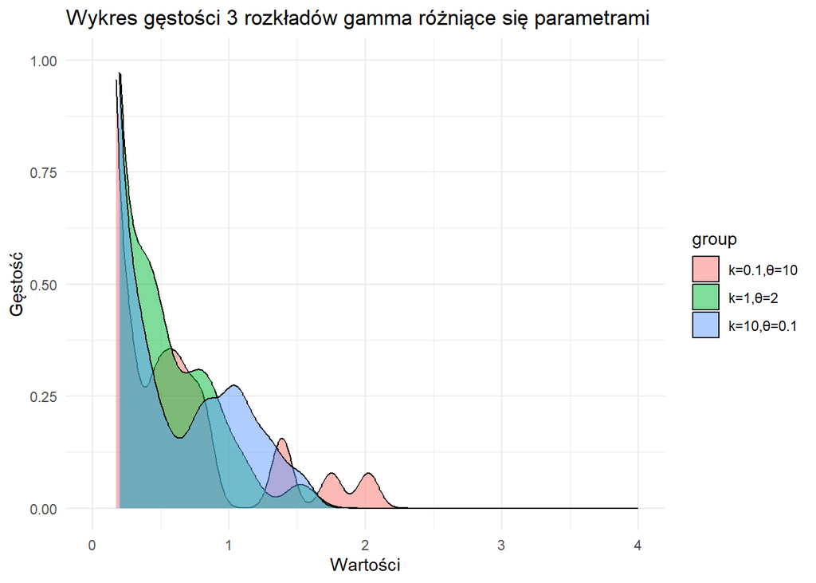

```r
  set.seed(395161225)
ggplot(r, aes(x = value, fill = group)) +
          geom_density(alpha = 0.5) +
          labs(title = "Wykres gęstości 3 rozkładów gamma różniące się parametrami",
               x = "Wartości",
               y="Gęstość") +
          theme_minimal()+
          xlim(0, 4) +
          ylim(0, 1)
```

Jak możemy zauważyć wykresy różnią się w zależności od podanych parametrów.

## **Funkcje**

```r
 statystyka <- function(q, n, k, t = 1) {
        set.seed(395161225)
        wektor <- rep(0, 300)
        for (i in 1:300) {
          o <- c(rgamma(n, k, t))^q
          z <- mean(o)
          wektor[i] <- z
        }
        return(wektor)
 }
```

Funkcja służąca do generowania **k** danych z rozkładu gamma. Pierwszym argumentem jest **q**, które służy do podnoszenia wylosowanych wartości do dowolnej potęgi, w naszym przypadku **q** będzie przyjmowało wartości 1, do wariantu 1 oraz 2, do wariantu drugiego aby podnieść do kwadratu wylosowane elementy; **k** to pierwszy parametr, a **t** przedstawia parametr teta, który zawsze jest równy 1. Z wygenerowanych danych funkcja oblicza średnią arytmetyczną i wpisuje do pustego wektora. Cały proces jest powtarzany 300 razy.

Funkcja zwraca ten wektor 300 średnich arytmetycznych.

```r
generowanie_charakterystyki <- function(q,n,k){
        set.seed(395161225)
        charakterystyki_rozkladu <- data.frame(
          n = numeric(0),
          "Średnia" = numeric(0),
          "Odchylenie standardowe" = numeric(0),
          "Skośność"=numeric(0),
          "Kurtoza"=numeric(0),
          "Rozkład normalny" = logical(0),
          check.names = FALSE
        )
        for (i in n) {
          set.seed(395161225)
          dane_w_zaleznosci_od_n <- statystyka(q,i, k)
          charakterystyki_rozkladu <- rbind(charakterystyki_rozkladu, data.frame(
            "k"=k,
            n = i,
            "Średnia" = round(mean(dane_w_zaleznosci_od_n),5),
            "Odchylenie std." = round(sd(dane_w_zaleznosci_od_n),5),
            "Skośność"=round(skewness(dane_w_zaleznosci_od_n),5),
            "Kurtoza"=round(kurtosis(dane_w_zaleznosci_od_n),5),
            "Rozkładn nor." = ifelse(shapiro.test(dane_w_zaleznosci_od_n)$p.value > 0.05,"Tak","Nie")
            ,check.names = FALSE
            ))}
          return(charakterystyki_rozkladu)}
```

Funkcja służąca do wygenerowania statystyk opisowych rozkładu, która wykorzystuje funkcję `statystyka` i przyjmuje jako argumenty **q**, czyli liczbę określającą potęgę, do której wylosowane dane zostaną podniesione, **n** czyli ilość wylosowanych danych, w naszym przypadku wyżej podany wektor **n** oraz **k** czyli parametr rozkładu gamma (0.1,1,10). Po podaniu parametrów i wywołaniu funkcji, zwracana jest tabelka danych zawierająca średnią, odchylenie standardowe oraz odpowiedź na to czy jest to rozkład normalny.

Statystyki opisowe obliczamy dzięki wbudowanym funkcjom w R: (`mean` oraz `sd`) i funkcjom z biblioteki `moments`: (`skewness` oraz `kurtosis`)

Jeśli chodzi o test normalności rozkładu, używamy funkcji `shapiro.test`, przyjmując poziom istotności α = 0.05.:

- **H0**: Próba pochodzi z rozkładu normalnego.
- **H1**: Próba nie pochodzi z rozkładu normalnego.

Jeśli `p.value<0,05`, oznacza to, że rozkład nie jest normalny, dlatego funkcja zwraca odpowiedź **“Nie”**, jeśli `p.value>0.05`, oznacza to, że **H0** jest prawdziwe, więc zwracana jest wartość **“Tak”**

```r
  wykres_gestosci <- function(q, n, k) {
  set.seed(395161225)
  dane <- data.frame(value = numeric(0), group = character(0))

  for (z in n) {
    wektor <- statystyka(q, z, k)
    dane <- rbind(dane, data.frame(value = wektor,
                                   group = rep(paste("k =", k, "θ = 1", "n =", z))))

  }
  dane$group <- factor(dane$group, levels = unique(dane$group[order(match(dane$group, n))]))

  x_range <- range(dane$value)
  y_range <- c(0, 20)

  return(
    ggplot(dane, aes(x = value, fill = group)) +
            geom_density( alpha = 0.5) +
      labs(title = "Wykres gęstości średnich w zależności od n",
           x = "Wartości", y = "Gęstość", fill = "Legenda") +
      theme_minimal() +
      xlim(x_range) +
      ylim(y_range)
  )
}
```

Funkcja służąca do narysowania wykresów gęstości w zalezności od **n**, która za argumenty przyjmuje **q**, czyli liczbę określającą potęgę, do której wylosowane dane zostaną podniesione, **n** czyli ilość danych, które losujemy, oraz parametr rozkładu **k**.

Funkcja zwraca nałożone na siebie wykresy gęstości, opatrzone legendą.

```r
wykres_pudelkowy <- function(q, n, k) {
        set.seed(395161225)
        dane <- data.frame(value = numeric(0), group = character(0))

        for (z in n) {
          wektor <- statystyka(q,z, k)
          dane <- rbind(dane, data.frame(value = wektor, group = z))
        }

        dane$group <- factor(dane$group)

        return(
          ggplot(dane, aes(x = factor(group), y = value, fill = group)) +
            geom_boxplot(alpha = 0.7, outlier.shape = "o") +
            labs(title = "Wykres pudelkowy w zależności od n", x = "", y = "Wartość") +
            theme_minimal() +
            scale_x_discrete(labels = n) +
            theme(axis.text.y = element_text(size = 8),
                  legend.position = "none")
        )
      }
```

Funkcja służąca do narysowania wykresów pudełkowych w zależności od **n**, która za argumenty przyjmuje **n**, parametr rozkładu **k**, oraz **q**.

Funkcja zwraca 9 wykresów pudełkowych, umieszczonych koło siebie, uporządkowane i opisane są według **n** rosnąco, czyli według ilości wylosowanych danych.

# **WARIANT 1**

## **Opis**

W wariancie pierwszym zajmujemy się badaniem **rozkładu zbioru średnich arytmetycznych**, wylosowanych z rozkładu gamma.Chcemy zobaczyć, jak rozkład średnich arytmetycznych zmienia się wraz ze wzrostem liczby danych wykorzystanych do obliczenia średniej, oraz jak zmienia się w zależności od charakterystyk rozkładu, w naszym przypadku, jak zmienia się parametr **k**.

## **Przedstawienie charakterystyk**

### Statystyki opisowe

**Dla k=0.1**

```r
k01 <- generowanie_charakterystyki(1, n, 0.1)
print(k01[-7])
```

```
##     k    n Średnia Odchylenie std. Skośność  Kurtoza
## 1 0.1    5 0.08907         0.13108  3.03563 15.92894
## 2 0.1   10 0.09663         0.09874  1.89896  7.38848
## 3 0.1   20 0.10027         0.07624  1.48654  5.58897
## 4 0.1   30 0.10523         0.06035  0.98991  3.89199
## 5 0.1   50 0.10562         0.04879  0.84531  3.76004
## 6 0.1  100 0.10253         0.03515  0.67024  3.23476
## 7 0.1  200 0.10248         0.02619  0.76406  4.24229
## 8 0.1  500 0.10064         0.01434  0.36899  3.42882
## 9 0.1 1000 0.10084         0.01041  0.32296  2.95800
```

**Dla k=1**

```r
k1 <- generowanie_charakterystyki(1,n,1)
print(k1[-7])
```

```
##   k    n Średnia Odchylenie std. Skośność Kurtoza
## 1 1    5 0.98443         0.43753  0.80689 3.90050
## 2 1   10 0.99723         0.29770  0.33812 2.86827
## 3 1   20 0.99805         0.21546  0.26500 2.52297
## 4 1   30 0.99808         0.17635  0.41326 3.09617
## 5 1   50 0.99482         0.13589  0.23897 3.05343
## 6 1  100 0.99967         0.09645  0.14031 3.17920
## 7 1  200 0.99987         0.06773  0.04078 2.82212
## 8 1  500 1.00326         0.04510  0.19454 3.31632
## 9 1 1000 1.00172         0.03036  0.36458 3.32142
```

**Dla k=10**

```r
k10 <- generowanie_charakterystyki(1,n,10)
print(k10[-7])
```

```
##    k    n  Średnia Odchylenie std. Skośność Kurtoza
## 1 10    5  9.88981         1.42415  0.35393 3.19015
## 2 10   10  9.97912         0.98027  0.16849 2.82158
## 3 10   20  9.97523         0.66716 -0.12757 2.63906
## 4 10   30  9.96069         0.58898  0.15700 2.80647
## 5 10   50  9.97033         0.47848  0.06920 2.80707
## 6 10  100 10.00556         0.31881 -0.14282 2.78134
## 7 10  200  9.99926         0.23857 -0.05201 3.07850
## 8 10  500 10.01255         0.14259 -0.07331 3.01577
## 9 10 1000 10.01340         0.10237 -0.06756 2.73699
```

Obserwujemy natomiast znaczny wzrost średniej wraz ze zwiekszaniem się parametru rozkładu k. Koresponduje to z wartością oczekiwaną, która dla poszczególnych k wynosi odpowiednio: 0.1, 1, 10.

**Odchylenie standardowe**, które informuje nas o tym jak wartości obserwacji są rozrzucone wokół średniej, stale maleje wraz ze wzrostem n, oznacza to, że wraz ze wzrostem n, dane są coraz bardziej skupione wokół średniej.

**Skośność** dla k = 0.1 maleje, jednak nawet dla n = 1000 i tak możemy zaobserwować wartość większą niż 0.3, co sugeruje skośność prawostronną.

Dla k = 1 skośność również maleje, przyjmując małe wartości (mniejsze niż 0.3) dla n = 50, 100, 200 i 500, jednakże wzrasta dla n = 1000. Ta różnica może być spowodowana ustawieniem przez nas konkretnego ziarna generatora.

Dla k = 10 skośność jest mała dla wszystkich opcji, z wyjątkiem n = 5.

**Kurtoza** Z powodu wysokiej asymetrii(skośności) dla k=0.1 nie intepretujemy kurtozy. W pozostałych przykładach gdzie skośność wynosi mniej niż 0.3, spłaszczenie rozkładu jest podobne do spłaszczenia rozkładu normalnego dla którego wynik funkcji kurtosis wynosi 3.

**WNIOSKI**: Możemy zauważyć, że dla małych wartości parametru k (k = 0.1) znaczny wpływ na symetrie ma liczba wygenerowanych danych, im większa liczba tym rozkład jest coraz bardziej zbliżony do symetrycznego. Dla większych wartości parametru k liczba wygenerowanych danych ma mniejszy wpływ na symetrię rozkładu: dla k = 10 praktycznie dla dowolnej liczby wylosowanych danych rozkład przypomina rozkład symetryczny.

## **Test normalności**

Jak już wcześniej założyliśmy, do rozpoznania czy rozkład jest normalny, użyjemy testu Shapiro Wilka, przyjmując poziom istotności α = 0.05.

- **H0**: Próba pochodzi z rozkładu normalnego.
- **H1**: Próba nie pochodzi z rozkładu normalnego.

Jeśli `p.value<0,05`, oznacza to, że rozkład nie jest normalny, dlatego funkcja zwraca odpowiedź **“Nie”**, jeśli `p.value>0.05`, oznacza to, że H0 jest prawdziwe, więc zwracana jest wartość **“Tak”**.

**Dla k=0.1**

```r
print(k01[, c(1, 2, 7)])
```

```
##     k    n Rozkładn nor.
## 1 0.1    5           Nie
## 2 0.1   10           Nie
## 3 0.1   20           Nie
## 4 0.1   30           Nie
## 5 0.1   50           Nie
## 6 0.1  100           Nie
## 7 0.1  200           Nie
## 8 0.1  500           Nie
## 9 0.1 1000           Nie
```

Jak możemy zauważyć, w naszym przypadku odrzucamy hipotezę **H0** we wszystkich przypadkach.

**Dla k=1**

```r
print(k1[, c(1, 2, 7)])
```

```
##   k    n Rozkładn nor.
## 1 1    5           Nie
## 2 1   10           Nie
## 3 1   20           Nie
## 4 1   30           Nie
## 5 1   50           Tak
## 6 1  100           Tak
## 7 1  200           Tak
## 8 1  500           Tak
## 9 1 1000           Nie
```

Dla k = 1 jedynie dla n = 50, 100, 200 i 500 nie odrzucamy hipotezy **H0**, uznając że rozkład w tych przypadkach jest normalny. Wracając do statystyk opisowych dla k = 1, widzimy, że właśnie dla tych n, zarówno kurtoza jak i skośność osiągały niskie wartości.

**Dla k=10**

```r
print(k10[, c(1, 2, 7)])
```

```
##    k    n Rozkładn nor.
## 1 10    5           Nie
## 2 10   10           Tak
## 3 10   20           Tak
## 4 10   30           Tak
## 5 10   50           Tak
## 6 10  100           Tak
## 7 10  200           Tak
## 8 10  500           Tak
## 9 10 1000           Tak
```

Widzimy, że tylko dla n = 5 nie stwierdzamy normalności rozkładu, może to być spowodowane generowanymi przez nas danymi, ograniczonymi przez ziarno generatora.

**WNIOSKI**: Jak możemy zauważyć dla małych wartości parametru k istnieje bardzo mała szansa, że rozkład jest normalny, nawet dla dużych n. Natomiast dla większych k jest duża szansa, że rozkład jest normalny. Więc, im większe k i n, tym większa szansa, że rozkład jest normalny.

## **Wykresy gęstości**

Aby porównać kształt rozkładu według poszczególnych k (parametru rozkładu), wszystkie nałożyliśmy na siebie, w celu lepszej obserwacji i wyciągnięcia wniosków.

**Dla k=0.1**

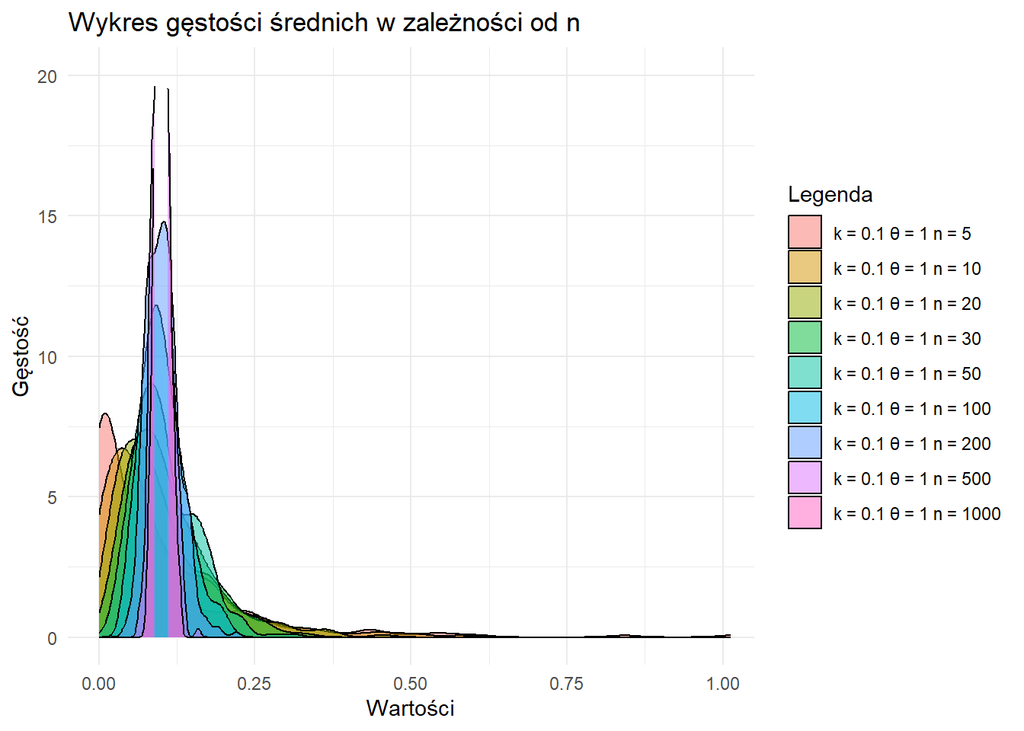

```r
k01w <- wykres_gestosci(1,n,0.1)
k01w <- k01w + coord_cartesian(xlim = c(0, 1), ylim = c(0, 20))
print(k01w)
```

Jak widać na wykresie, dla większych n obserwacje są coraz bardziej skupione wokół średniej, jednak jak już wiemy, nie na tyle, aby rozkład był normalny. Możemy ponadto dostrzec w jaki sposób skośność i odchylenie standardowe maleją oraz w jak dużym stopniu wzrost n wpływa na rozmieszczenie obserwacji.

**Dla k=1**

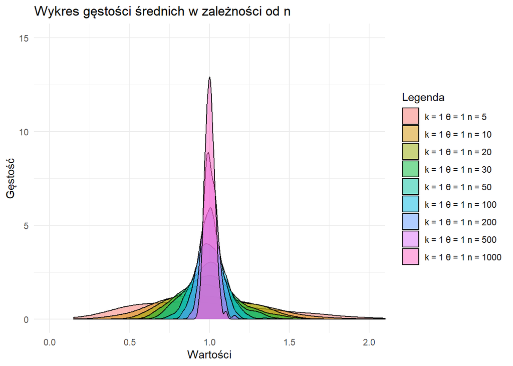

```r
k1w <- wykres_gestosci(1,n,1)
k1w <- k1w + coord_cartesian(xlim = c(0, 2), ylim = c(0, 15))
print(k1w)
```

Dla k = 1 możemy zaobserwować większe podobieństwo do rozkładu normalnego, obserwację są w znacznej mierze skupione wokół średniej, wykres jest mniej strzelisty w stosunku do poprzedniego.

**Dla k=10**

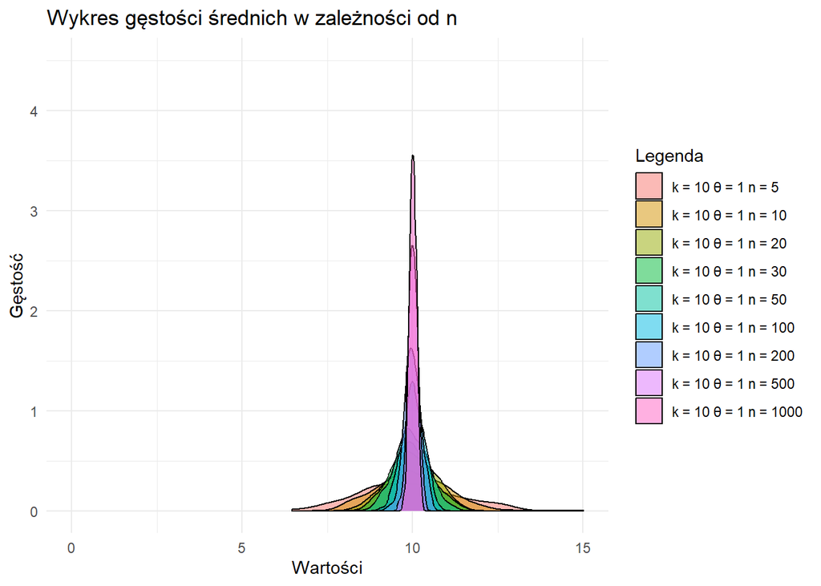

```r
k10w <- wykres_gestosci(1,n,10)
k10w <- k10w + coord_cartesian(xlim = c(0, 15), ylim = c(0, 4.5))
print(k10w)
```

Z wykresu wynika, że dla dużego k = 10, wielkość obserwacji n nie wpływa znacząco na rozkład, jest on jak widać bardzo podobny do rozkładu normalnego.

**WNIOSKI**: Przedstawione wykresy gęstości w przejrzysty sposób pokazują nam wyciągnięte wcześniej wnioski dotyczące wpływu wielkości parametru k oraz liczby danych n na rozkład.

## **Wykresy pudełkowe**

W celu lepszego porównania, wszystkie wykresy pudełkowe, ustawiliśmy koło siebie.

**Dla k=0.1**

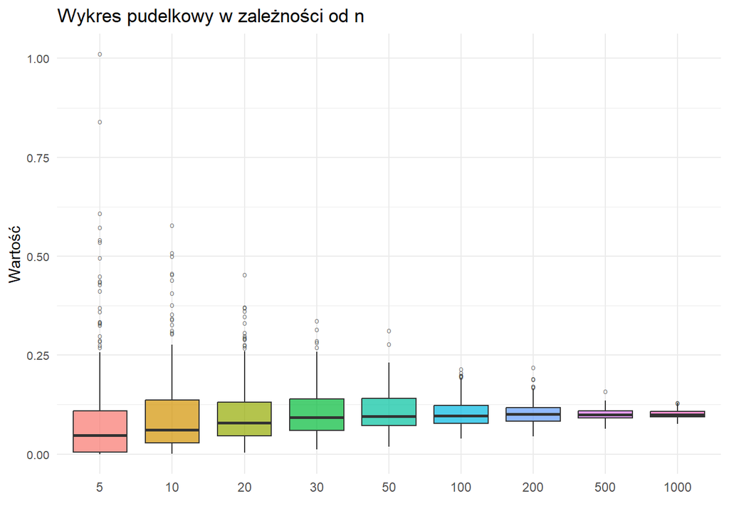

```r
k01pd <- wykres_pudelkowy(1,n,0.1)
print(k01pd)
```

Jak widać wraz ze wzrostem n pudełka są coraz bardziej “spłaszczone”, oraz występuje coraz mniej wartości odstających, co sugeruje skoncentrowanie obserwacji w środku (w pobliżu mediany).

**Dla k=1**

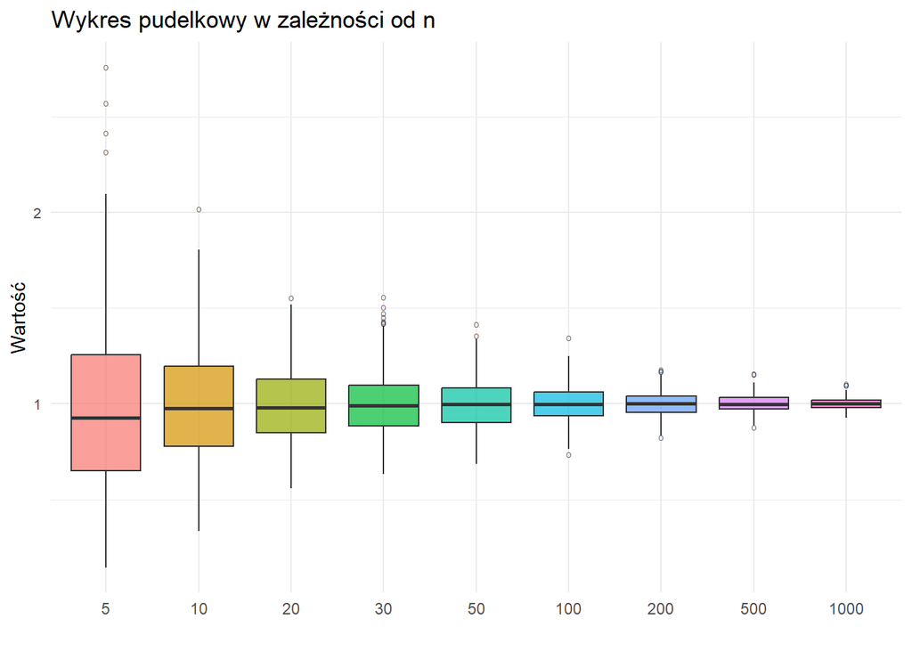

```r
k1pd <- wykres_pudelkowy(1,n,1)
print(k1pd)
```

Widzimy, że przy zmianie k = 1, pudełka są, podobnie jak w poprzedniej sytuacji, coraz bardziej spłaszczone i występuje mniej outlierów, ale ponadto rozmieszczenie danych jest coraz bardziej symetrzyczne.

**Dla k=10**

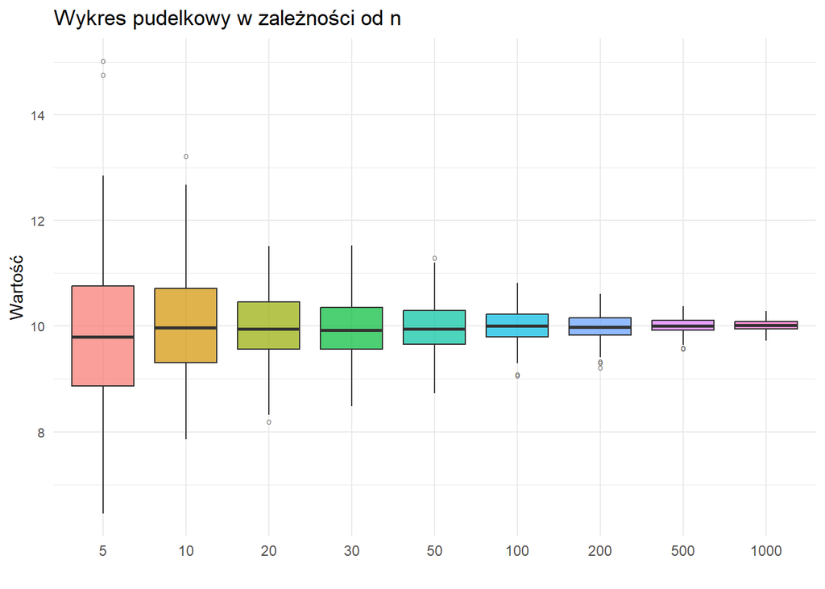

```r
k10pd <- wykres_pudelkowy(1,n,10)
print(k10pd)
```

Możemy zauważyć, że dla k = 10, outliery występują sporadycznie, można bardzo wyraźnie dostrzec symetrię rozkładu i analogicznie, skupienie obserwacji w pobliżu mediany.

**WNIOSKI**: Na podstawie obserwacji wykresów pudełkowych możemy dostrzec, że im większe k i n, tym obserwacje są coraz bardziej skupione wokół mediany i rozkład jest symetryczny.

# **WARIANT 2**

## **Opis**

W wariancie drugim zajmujemy się badaniem **rozkładu zbioru średnich arytmetycznych,** wylosowanych z rozkładu gamma,którego wartości przed obliczeniem średniej podniesiono do kwadatu.Chcemy zobaczyć, jak rozkład średnich arytmetycznych zmienia się wraz ze wzrostem liczby danych wykorzystanych do obliczenia średniej, oraz jak zmienia się w zależności od charakterystyk rozkładu, w naszym przypadku, jak zmienia się parametr k, wszystko po podniesieniu do kwadratu wylosowanyach przez nas elementów.(**q**=2).

## **Przedstawienie charakterystyk**

### Statystyki opisowe

**Dla k=0.1**

```r
k012 <- generowanie_charakterystyki(2, n, 0.1)
print(k012[-7])
```

```
##     k    n Średnia Odchylenie std. Skośność   Kurtoza
## 1 0.1    5 0.09884         0.39074  9.16896 104.17866
## 2 0.1   10 0.10983         0.27746  5.55726  40.61762
## 3 0.1   20 0.12377         0.25055  5.56501  46.96933
## 4 0.1   30 0.12405         0.17968  4.36060  32.90252
## 5 0.1   50 0.12453         0.13190  2.79923  15.90814
## 6 0.1  100 0.11595         0.09193  1.94176   8.05076
## 7 0.1  200 0.11637         0.06937  1.90271   9.59011
## 8 0.1  500 0.11121         0.03801  1.20363   5.77149
## 9 0.1 1000 0.11193         0.02713  0.78666   4.15426
```

**Dla k=1**

```r
k12 <- generowanie_charakterystyki(2,n,1)
print(k12[-7])
```

```
##   k    n Średnia Odchylenie std. Skośność  Kurtoza
## 1 1    5 1.91446         1.82538  2.42216 11.82275
## 2 1   10 1.94867         1.25851  1.38260  5.51461
## 3 1   20 1.97343         0.93343  0.91091  3.52364
## 4 1   30 1.98046         0.79549  0.92080  3.94524
## 5 1   50 1.96423         0.59079  0.72505  4.03466
## 6 1  100 1.99156         0.42820  0.48218  3.14070
## 7 1  200 1.98544         0.30060  0.31397  3.03940
## 8 1  500 2.00462         0.20283  0.49223  3.39642
## 9 1 1000 2.00495         0.13609  0.41656  3.35326
```

**Dla k=10**

```r
k102 <- generowanie_charakterystyki(2,n,10)
print(k102[-7])
```

```
##    k    n  Średnia Odchylenie std. Skośność Kurtoza
## 1 10    5 108.2965        32.24114  1.01220 5.51338
## 2 10   10 110.1055        21.92287  0.53178 3.43131
## 3 10   20 109.5632        14.71356  0.11815 2.92417
## 4 10   30 109.2407        13.27870  0.32016 2.98018
## 5 10   50 109.4620        10.62820  0.17601 2.77879
## 6 10  100 110.1529         7.04609 -0.13109 2.71747
## 7 10  200 110.0247         5.30566 -0.03232 3.04213
## 8 10  500 110.3012         3.28605 -0.11410 2.99519
## 9 10 1000 110.3343         2.33946 -0.04056 2.78582
```

**Średnia**, podobnie jak dla wariantu nr 1, wraz ze wzrostem n, prawie się nie zmienia dla poszczególnych k. Ma lekką tendecję zwyżkową.

**Odchylenie standardowe** stale maleje wraz ze wzrostem n we wszystkich przypadkach parametru k, oznacza to, że wraz ze wzrostem n, dane są coraz bardziej skupione przy średniej.

**Skośność** podobnie jak w wariancie nr 1, zmniejsza się wraz ze wzrostem parametru k oraz liczby losowanych danych n. Jednakże dla małych n, skośność jest dużo silniejsza niż w wariancie nr 1.

**Kurtoza** dla k = 0.1 osiąga kolosalne wartości,ma na to duży wpływa wysoka wartość skośności, zbliża się jednak do 3 i znacznie zmniejsza wraz ze wzrostem liczby obserwacji n.

Dla pozostałych k, dopiero dla n większych od 20 (w przypadku k = 1) oraz większych od 10 (w przypadku k = 10) kurtoza osiąga wartości zbliżone do 3.

Mimo to przez skośność dużo większą niż 0.3 nie można dobrze zintepretować kurtozy dla więszkości przypadków.

**WNIOSKI**: Przedstawione statystyki w Wariancie nr 2, różnią się od tych z Wariantu nr 1, główną różnicę widać w skośności i kurtozie, które dla małych ilości obserwacji n, osiągają znacznie większe wartości niż w Wariancie nr 1.

## **Test normalności**

Jak już wcześniej założyliśmy, do rozpoznania czy rozkład jest normalny, użyjemy testu Shapiro Wilka, przyjmując poziom istotności α = 0.05. Dla przypomnienia:

- **H0**: Próba pochodzi z rozkładu normalnego.
- **H1**: Próba nie pochodzi z rozkładu normalnego.

Jeśli `p.value<0,05`, oznacza to, że rozkład nie jest normalny, dlatego funkcja zwraca odpowiedź **“Nie”**, jeśli `p.value>0.05`, oznacza to, że H0 jest prawdziwe, więc zwracana jest wartość **“Tak”**.

**Dla k=0.1**

```r
print(k012[, c(1, 2, 7)])
```

```
##     k    n Rozkładn nor.
## 1 0.1    5           Nie
## 2 0.1   10           Nie
## 3 0.1   20           Nie
## 4 0.1   30           Nie
## 5 0.1   50           Nie
## 6 0.1  100           Nie
## 7 0.1  200           Nie
## 8 0.1  500           Nie
## 9 0.1 1000           Nie
```

Widzimy, że dla k = 0.1 żadne z przyjętych przez nas n nie zmieniło wyniku testu: odrzucamy hipotezę **H0** we wszystkich przypadkach, uznając, że rozkłady te nie są normalne.

**Dla k=1**

```r
print(k12[, c(1, 2, 7)])
```

```
##   k    n Rozkładn nor.
## 1 1    5           Nie
## 2 1   10           Nie
## 3 1   20           Nie
## 4 1   30           Nie
## 5 1   50           Nie
## 6 1  100           Nie
## 7 1  200           Tak
## 8 1  500           Nie
## 9 1 1000           Nie
```

Dla k = 1 tylko w przypadku n = 200 widzimy, że hipoteza **H0** nie została odrzucona, zatem tylko wtedy rozkład jest uznany za normalny.

**Dla k=10**

```r
print(k102[, c(1, 2, 7)])
```

```
##    k    n Rozkładn nor.
## 1 10    5           Nie
## 2 10   10           Nie
## 3 10   20           Tak
## 4 10   30           Nie
## 5 10   50           Tak
## 6 10  100           Tak
## 7 10  200           Tak
## 8 10  500           Tak
## 9 10 1000           Tak
```

Widzimy, że dopiero dla k = 10 występuje zmiana w wynikach testu Shapiro-Wilka. Hipoteza H0 została odrzucona jedynie dla n = 5, 10 i 30, w pozostałych przypadkach rozkład jest normalny.

**WNIOSKI**: Jak możemy zauważyć w tym wariancie parametr k = 0.1 i 1, nie daje nam dużej szansy na to, aby rozkład był normalny, dopiero dla k = 10, wraz ze wzrostem n dostrzegamy normalność rozkładu, wynikającą z testu Shapiro-Wilka.

## **Wykresy gęstości**

Aby porównać kształt rozkładu według poszczególnych k(parametru rozkładu), wszystkie nałożyliśmy na siebie, w celu lepszej obserwacji i wyciągnięcia wniosków.

**Dla k=0.1**

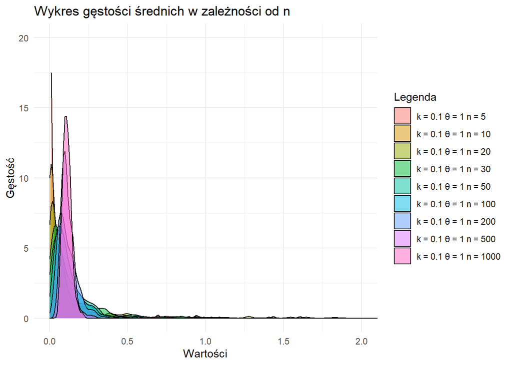

```r
k01w2 <- wykres_gestosci(2, n, 0.1)
k01w2 <- k01w2 + coord_cartesian(xlim = c(0, 2), ylim = c(0, 20))
print(k01w2)
```

Jak widać parametr n wpływa na rozkład, jednakże nie czyni go zbliżonym do normalnego, występuje nadal zbyt duża skośność i kurtoza.

**Dla k=1**

```r
  k1w2 <- wykres_gestosci(2,n,1)
k1w2 <- k1w2 + coord_cartesian(xlim = c(0, 6), ylim = c(0, 5))
 print(k1w2)
```

[figure not shown]

Możemy zaobserwować, że dla k = 1 wykresy są bardziej spłaszczone i symetryczne, co czyni je zbliżonymi do rozkładu normalnego, jednak test Shapiro-Wilka wykazał go tylko dla n = 200. Może to być spowodowane ustalonym przez nas ziarnem generatora, lub sporymi wartościami odstającymi, co sprawdzimy później za pomocą wykresy pudełkowego.

**Dla k=10**

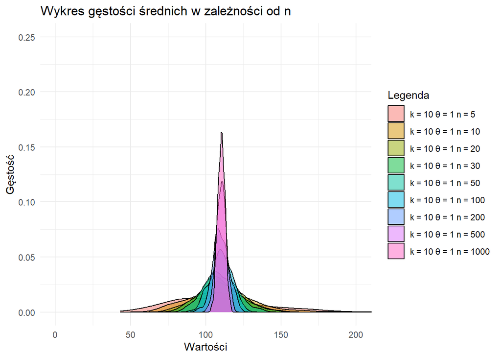

```r
k10w2 <- wykres_gestosci(2,n,10)
k10w2 <- k10w2 + coord_cartesian(xlim = c(0, 200), ylim = c(0, 0.25))
print(k10w2)
```

Wykres ten jest najbardziej symetryczny ze wszystkich, w dodatku jest mocno spłaszczony w porównaniu do pozostałych.

**WNIOSKI**: Przedstawione wykresy gęstości obrazują nam, że dla dużych k i n rozkład jest coraz bardziej symetryczny, a co za tym idzie, zbliżony do rozkładu normalnego

## **Wykresy pudełkowe**

W celu lepszego porównania, wszystkie wykresy pudełkowe, ustawiliśmy koło siebie.

**Dla k=0.1**

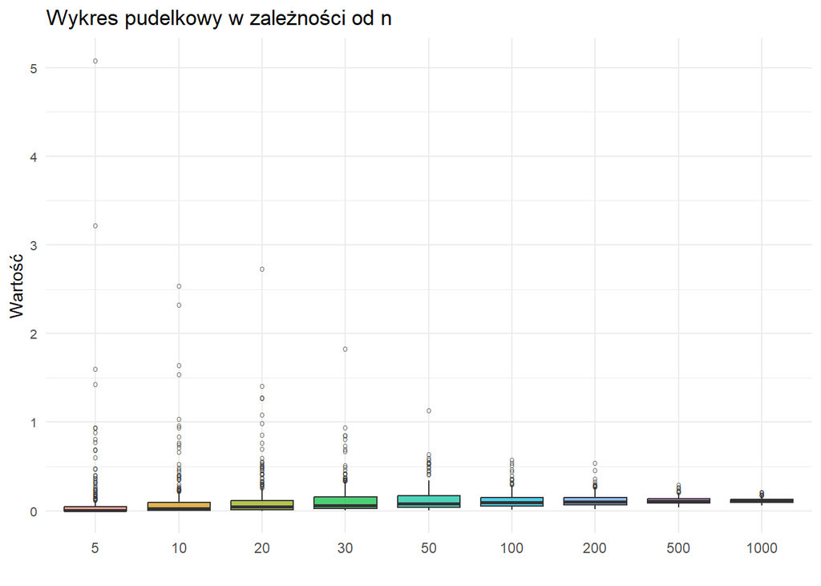

```r
k01pd2 <- wykres_pudelkowy(2,n,0.1)
print(k01pd2)
```

Jak widać, wykres ten różni się od przedstawionego przez nas w Wariancie nr 1, występuje znacznie więcej outlierów, w szczególności dla małych n, ponadto outliery są nagromadzone po jednej ze stron, co sugeruje znaczną asymetrię rozkładu.

**Dla k=1**

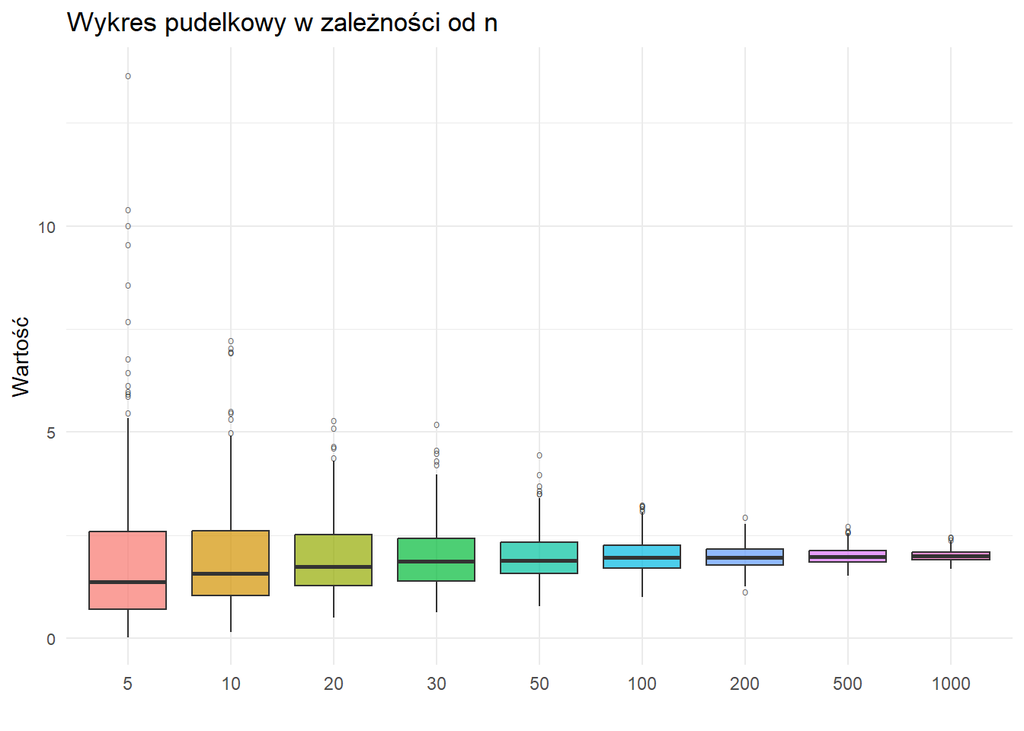

```r
k1pd2 <- wykres_pudelkowy(2,n,1)
print(k1pd2)
```

W tym przypadku, przy zwiększeniu k do równego 1 widzimy zmniejszenie ilości outlierów i większą symetrię rozkładu oraz “spłaszczanie” się pudełek wraz ze wzrostem ilości obserwacji n.

**Dla k=10**

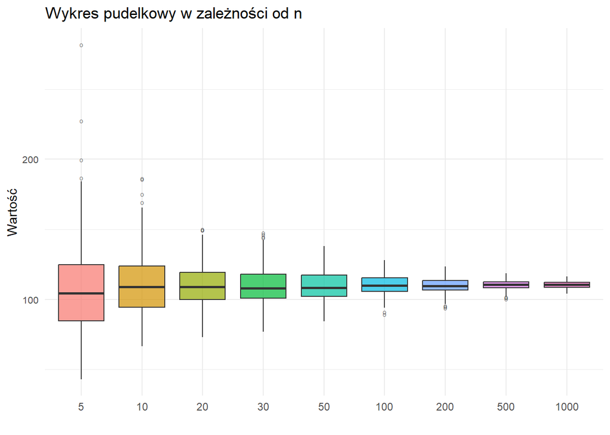

```r
k10pd2 <- wykres_pudelkowy(2,n,10)
print(k10pd2)
```

Dla parametru k = 10 widzimy dużą symetrię, w szczególności dla większych n. Ilość występujących wartości odstających jest niewielka, obserwacje są zgromadzone coraz bardziej wokół mediany wraz ze wzrotem n.

**WNIOSKI**: Wariant ten różni się od wariantu nr 1, jednakże obrazuje podobne zależności, otóż wraz ze wzrostem parametru k rozkład staje się coraz bardziej symetryczny, a wzrost ilości losowanych danych wpływa na “spłaszczenie” pudełka, czyli nagromadznie obserwacji w środku, wokół mediany.